# ST661-R for Data Analytics Mini Project(Group-10)

JINGCHEN ZHANG, NARESH KUMAR NAGARAJ, ILIA POSTOLOV & ERNESTAS KRIAUCIUNAS

## Irish Weather Warnings for 2017

### Synopsis

**Introduction** : Weather warnings and how different parts of Ireland experienced them. The weather warning analysis was carried out on the aimsir17 dataset package, which includes all-weather station observations for the year 2017. This dataset consists of 219,000 rows, where each row corresponds to an hourly recording for each of the 25 stations throughout Ireland. The locations of each station are shown below.

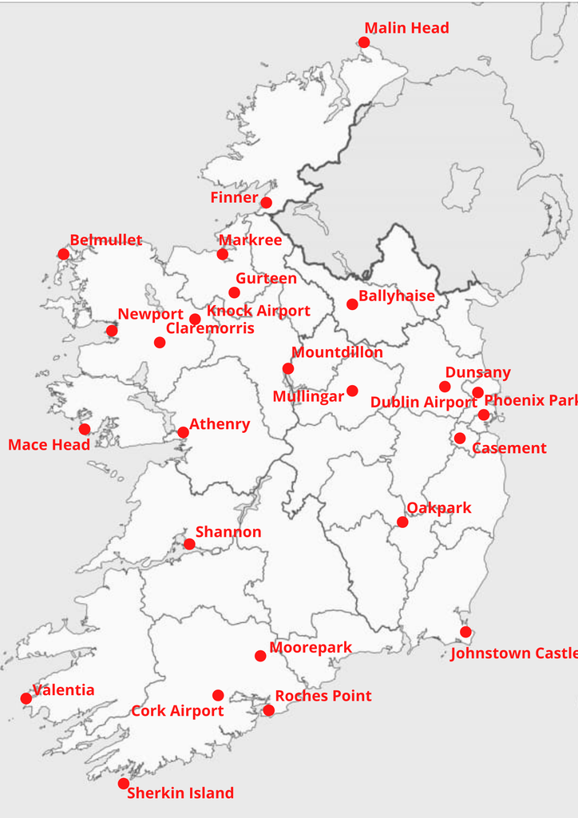

Station locations

**Authors’ statements** :

I ERNESTAS KRIAUCIUNAS had primary responsibility for the material in section Synopsis, Summary, and General analysis section under Data Analysis tab.  
I ILIA POSTOLOV had primary responsibility for the data set in the section Data Preparation tab.  
I NARESH KUMAR NAGARAJ had primary responsibility for the material in section Storm Ophelia and the plots in section General Analysis section under Data Analysis tab.  
I JINGCHEN ZHANG had primary responsibility for the part Rain vs Wind in section General Analysis under Data Analysis tab.

### Packages Requirement

The following packages were used in the project:

- aimsir17
- ggplot2
- dplyr
- Knitr
- tidyr
- shiny
- stringr
- tidyverse

### Data Preparation

This section describes the main steps undertaken in the current analysis.

#### Data Import

**Source of Data** : “Irish weather data for 2017” is available from package aimsir17.

**Data Name** : observations  
**Import command** :  
A short summary of what is contained within the main dataset is shown here:

```r
options(width = 120)
data<- observations
head(data)
```

```
## # A tibble: 6 x 12
##   station  year month   day  hour date                 rain  temp  rhum   msl  wdsp wddir
##   <chr>   <dbl> <dbl> <int> <int> <dttm>              <dbl> <dbl> <dbl> <dbl> <dbl> <dbl>
## 1 ATHENRY  2017     1     1     0 2017-01-01 00:00:00   0     5.2    89 1022.     8   320
## 2 ATHENRY  2017     1     1     1 2017-01-01 01:00:00   0     4.7    89 1022      9   320
## 3 ATHENRY  2017     1     1     2 2017-01-01 02:00:00   0     4.2    90 1022.     8   320
## 4 ATHENRY  2017     1     1     3 2017-01-01 03:00:00   0.1   3.5    87 1022.     9   330
## 5 ATHENRY  2017     1     1     4 2017-01-01 04:00:00   0.1   3.2    89 1023.     8   330
## 6 ATHENRY  2017     1     1     5 2017-01-01 05:00:00   0     2.1    91 1023.     8   330
```

The following variables are recored for each observation:

- station (weather station name)
- year (2017)
- month (month of year 1-12)
- day (day of month 1-31)
- date (date object in R)
- rain (hourly rainfall in mm)
- temp (hourly temperature in C)
- rhum (Relative Humidity - percent)
- msl (Mean Sea Level Pressure - hPa)
- wdsp (Mean Wind Speed - knots)
- wddir (Predominant Wind Direction - degree)

```r
colnames(data)
```

```
##  [1] "station" "year"    "month"   "day"     "hour"    "date"    "rain"    "temp"    "rhum"    "msl"     "wdsp"
## [12] "wddir"
```

Dimension of the table:

```r
dim(data)
```

```
## [1] 219000     12
```

#### Data Preview

```r
options(width = 120)
head(data)
```

```
## # A tibble: 6 x 12
##   station  year month   day  hour date                 rain  temp  rhum   msl  wdsp wddir
##   <chr>   <dbl> <dbl> <int> <int> <dttm>              <dbl> <dbl> <dbl> <dbl> <dbl> <dbl>
## 1 ATHENRY  2017     1     1     0 2017-01-01 00:00:00   0     5.2    89 1022.     8   320
## 2 ATHENRY  2017     1     1     1 2017-01-01 01:00:00   0     4.7    89 1022      9   320
## 3 ATHENRY  2017     1     1     2 2017-01-01 02:00:00   0     4.2    90 1022.     8   320
## 4 ATHENRY  2017     1     1     3 2017-01-01 03:00:00   0.1   3.5    87 1022.     9   330
## 5 ATHENRY  2017     1     1     4 2017-01-01 04:00:00   0.1   3.2    89 1023.     8   330
## 6 ATHENRY  2017     1     1     5 2017-01-01 05:00:00   0     2.1    91 1023.     8   330
```

#### Data Description

**Data Cleaning** : The main variables of interest in our research are the rain and wdsp columns. Met Eireann issues weather warnings for regions where the total rainfall and/or strength of wind exceeds specific values. The severity of a warning can be broken down into 3 distinct categories named by color. For our columns of interest, these can be broken down into:

Weather warnings for 24-hour rainfall sum and wind speed values

|  | RainFall (mm) | wind speed(knots) |
| --- | --- | --- |
| Yellow | 30-50 | 27-35 |
| Orange | 50-80 | 35-43 |
| Red | 80+ | 43+ |

We start by creating new columns to add to the existing data set, that will give a weather warning classification based on the values shown above. The rain column is summed every 24 rows and if a match is made to one of the three classifications, then it is classified accordingly. For the days where there is no match, a “Clear” is stated. Similarly, for the wdsp column, each recording gets classified based on the above numbers and is labeled “Clear” if no match is made. To do this I had to use a For loop for each row in the column checking the sum and making “temporary” variables for comparison (the code for the aforementioned process is included below):

```r
library(aimsir17)
Data$RainLevel<- NA
Data$WindLevel <- NA
Data$WeatherLevel<- NA
Data$DayWindLevel <- NA
fT<-0
f<-0
WindLevel<-0

  for(i in 1:nrow(Data))
  {

    if(Data$hour[i] == 0){
    fT<-0
    f<-0
    DayTemp <- NA
    RainTemp <- 0 }

    WindTemp <- Data$wdsp[i]

    RainTemp <- RainTemp + Data$rain[i]

    ifelse (WindTemp < 27,Data$WindLevel[i]<-"Clear" ,ifelse(WindTemp < 35,Data$WindLevel[i]<-"Yellow" ,ifelse(WindTemp < 43,Data$WindLevel[i]<-"Orange" ,Data$WindLevel[i]<-"Red")) )

    ifelse (RainTemp < 30,Data$RainLevel[i]<-"Clear",ifelse(RainTemp < 50,Data$RainLevel[i]<-"Yellow",ifelse(RainTemp < 80,Data$RainLevel[i]<-"Orange",Data$RainLevel[i]<-"Red")))

    ifelse(Data$RainLevel[i]=="Yellow"  || Data$WindLevel[i]=="Yellow", fT <- 1,ifelse(Data$RainLevel[i] =="Orange" || Data$WindLevel[i] == "Orange",fT <-2,ifelse(Data$RainLevel[i]=="Red" || Data$WindLevel[i]=="Red", fT <-3, fT <- 0)))

     Hour <- Data$hour[i]

if (f < fT) f <- fT

if(!is.na(Data$wdsp[i])){if (WindLevel < Data$wdsp[i]) WindLevel <- Data$wdsp[i]}


    if(Hour == 23){
      if(f==0)  Data$WeatherLevel[i] <-"Clear"
      if(f==1)  Data$WeatherLevel[i] <-"Yellow"
      if(f==2)  Data$WeatherLevel[i] <-"Orange"
      if(f==3)  Data$WeatherLevel[i] <-"Red"

      if(WindLevel == 0)Data$DayWindLevel[i] <- NA
      else Data$DayWindLevel[i] <- WindLevel
      WindLevel <-0
    }
  }
head(Data)
write.csv2(Data, "New_Data_omit.csv")
```

Further data cleaning is needed since our RainLevel column gives the rain warning for the day and the WindLevel column gives the wdps warning for hourly values. A new column is made which classifies a wind warning for the whole day based on the severity of warnings that are detected in 24 hours, similarly to the RainLevel column. For example, if our algorithm were to detect an “orange” and a “yellow” warning in that period, we will classify the daily wind warning to be “orange” as this is the most severe warning detected.

This process allows filtering the 219,000 rows of data to just 8,369 rows as only 1 row of data for every 24 rows is kept with the relevant information. Every other row is omitted from the dataset so that we can look at the daily information recorded from the stations. Note also that the Phoenix Park and Markree stations did not record wind speed and so it got omitted from the original dataset which is why we reach 8,369 rows and not 219,000/24= 9,125 rows.

The last modification that is added is the WeatherLevel column that gives a summary of the most severe warning in place for that day. This takes into account both the RainLevel and the WindLevel columns to produce the summarized warning for the day. This is then followed by a new column called Warning that gives a “None” or a “Warning” factor for the day.

```
##     X.1     X   station year month day hour                date rain temp rhum    msl wdsp wddir RainLevel WindLevel
## 1  1296  1296   ATHENRY 2017     2  23   23 2017-02-23 23:00:00    0  2,8   81 1013,8    5   230     Clear     Clear
## 2  4848  4848   ATHENRY 2017     7  21   23 2017-07-21 23:00:00  0,3 11,9   94  998,4    9    50    Yellow     Clear
## 3  6936  6936   ATHENRY 2017    10  16   23 2017-10-16 23:00:00  0,1 10,2   85   1006   16   250     Clear     Clear
## 4  8592  8592   ATHENRY 2017    12  24   23 2017-12-24 23:00:00  0,6 10,9   94 1004,9   11   210    Yellow     Clear
## 5  8760  8760   ATHENRY 2017    12  31   23 2017-12-31 23:00:00  0,9    6   88  990,8   11   250     Clear     Clear
## 6 17712 17712 BELMULLET 2017     1   8   23 2017-01-08 23:00:00    0 10,8   86 1016,6   33   200     Clear    Yellow
##   WeatherLevel DayWindLevel Warning       DATE
## 1       Yellow       Yellow Warning 2017-02-23
## 2       Yellow        Clear Warning 2017-07-21
## 3       Yellow       Yellow Warning 2017-10-16
## 4       Yellow        Clear Warning 2017-12-24
## 5       Yellow       Yellow Warning 2017-12-31
## 6       Yellow       Yellow Warning 2017-01-08
```

```
##  [1] "X.1"          "X"            "station"      "year"         "month"        "day"          "hour"
##  [8] "date"         "rain"         "temp"         "rhum"         "msl"          "wdsp"         "wddir"
## [15] "RainLevel"    "WindLevel"    "WeatherLevel" "DayWindLevel" "Warning"      "DATE"
```

```
## [1] 436  20
```

### Data Analysis

#### General analysis

##### General Analysis and Changes in Irish Weather.

We analysed the total number of weather warnings that were recorded by each station. Days, where no weather warnings were in place, were omitted, and so we are left with a clear picture of the total weather events recorded by severity.

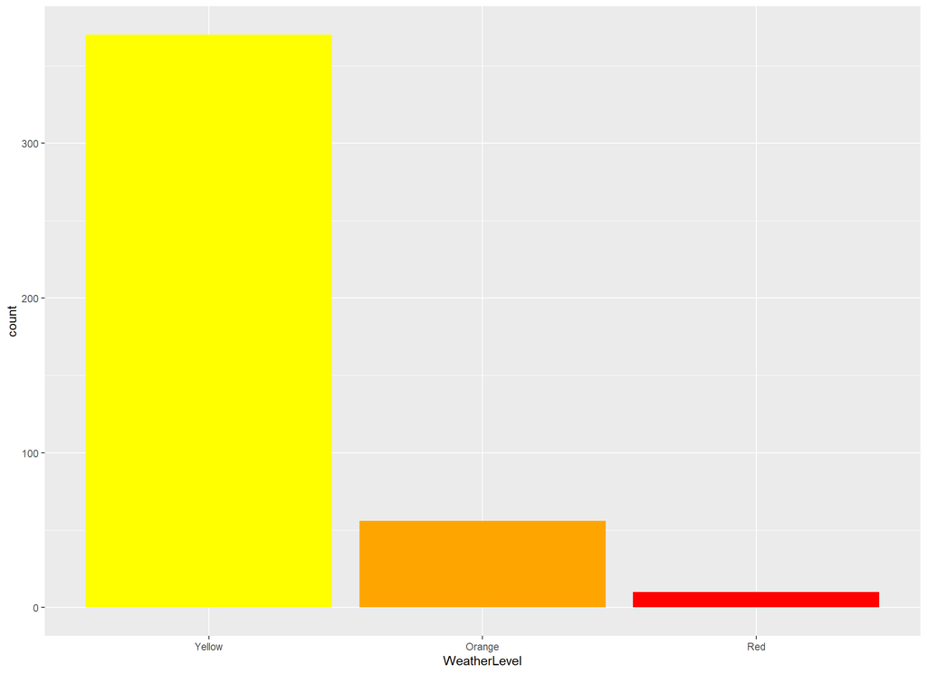

$\small{Figure}$ $\small{1:}$ $\small{Total}$ $\small{Weather}$ $\small{Warnings}$ $\small{based}$ $\small{on}$ $\small{classifications}$

In our analysis, we see that 436 station recordings had a weather event. The severity of these events decreases exponentially. We expect to see different regions of Ireland experiencing more/fewer weather events due to their locations.

We analyse how many weather events are recorded by the stations with the highest count of weather events below.

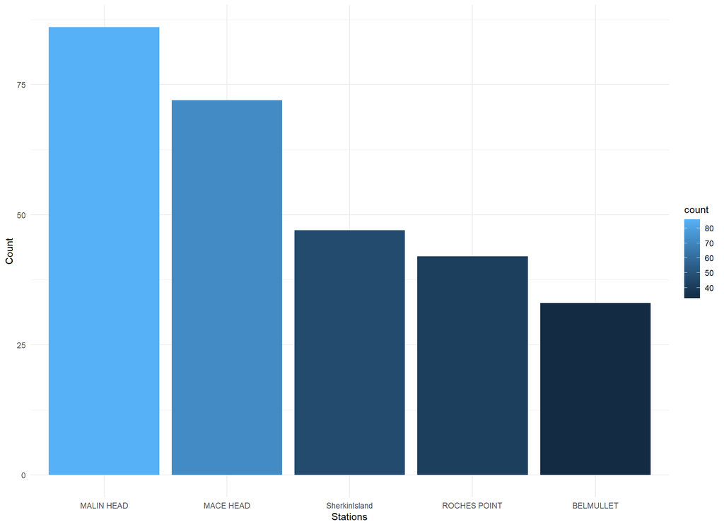

$\small{Figure}$ $\small{2:}$ $\small{Stations}$ $\small{with}$ $\small{Heighest}$ $\small{Weather}$ $\small{Warnings}$

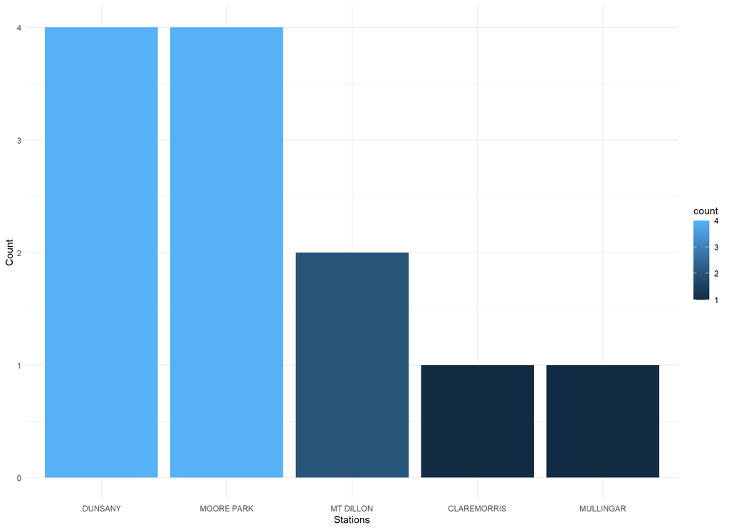

$\small{Figure}$ $\small{3:}$ $\small{Stations}$ $\small{with}$ $\small{Fewest}$ $\small{Weather}$ $\small{Warnings}$

This is a count of total weather events recorded by each station, note that out of 25 station recordings we are only left with 22 stations. This is due to Phoneix Park and Markree stations not providing any wdsp data and also having no rain warnings in their recordings. Another important note is that the station Ballyhaise had no weather warnings recorded, so the count is 0.

```r
count_frame_bally <- data2_omit %>% filter(station=="BALLYHAISE") %>% group_by(station="BALLYHAISE")%>% count(Warning, .drop=FALSE)
count_frame_bally
```

```
## # A tibble: 2 x 3
## # Groups:   station [1]
##   station    Warning     n
##   <chr>      <fct>   <int>
## 1 BALLYHAISE None      364
## 2 BALLYHAISE Warning     0
```

From this analysis, we can see that the top 5 stations accounted for 280 weather warnings in total. This is 64% of total weather warnings for the year. In comparison, the 5 stations with the fewest number of warnings account for only 2.7% of all-weather warnings.

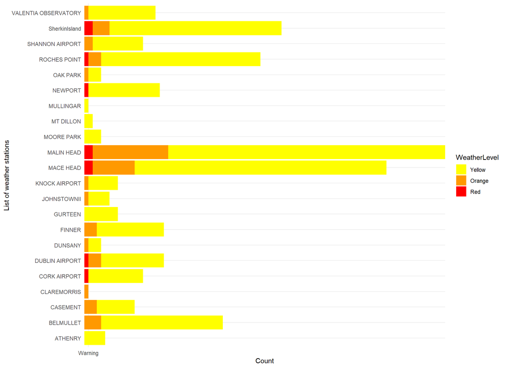

$\small{Figure}$ $\small{4:}$ $\small{Difference}$ $\small{in}$ $\small{Recorded}$ $\small{Weather}$ $\small{Events}$ $\small{by}$ $\small{Station}$

##### Rain vs Wind

For this analysis, we will only be looking at days when there is a weather warning, which implies that at least one element between rainfall and wind produced a warning.

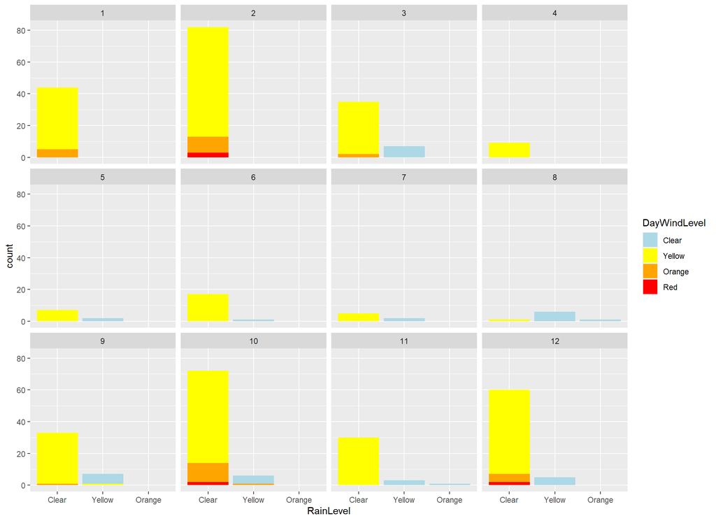

$\small{Figure}$ $\small{5:}$ $\small{Different}$ $\small{Levels}$ $\small{of}$ $\small{Wind}$ $\small{Warning}$ $\small{for}$ $\small{each}$ $\small{level}$ $\small{of}$ $\small{Rain}$ $\small{Warning}$ $\small{by}$ $\small{Month}$ $\small{across}$ $\small{all}$ $\small{Stations}$

##### Hypothesis Testing

To explore whether there is a correlation between rainfall and wind, we employed the method of hypothesis testing using chi-squared analysis.

Null hypothesis: when a rain warning is produced, a wind warning is also produced. i.e. the number of rain and wind warnings are equal

Alternative hypothesis: the number of rain and wind warnings are not equal

```r
rainWarningCount <- sum(omit_for_warning$RainLevel != "Clear")
windWarningCount <- sum(omit_for_warning$DayWindLevel != "Clear")
warningTable <- matrix(data=c(rainWarningCount,windWarningCount), nrow=1, ncol=2, byrow=T)
colnames(warningTable) <- c('Rain Warnings','Wind Warnings')

ctest <- chisq.test(warningTable)
ctest
```

```
##
##  Chi-squared test for given probabilities
##
## data:  warningTable
## X-squared = 289.35, df = 1, p-value < 2.2e-16
```

As we can see, the p-value is smaller than 0.05 by a great margin. The evidence very strongly suggests that the number of rain and wind warnings are not equal. We can also visualize this on a graph:

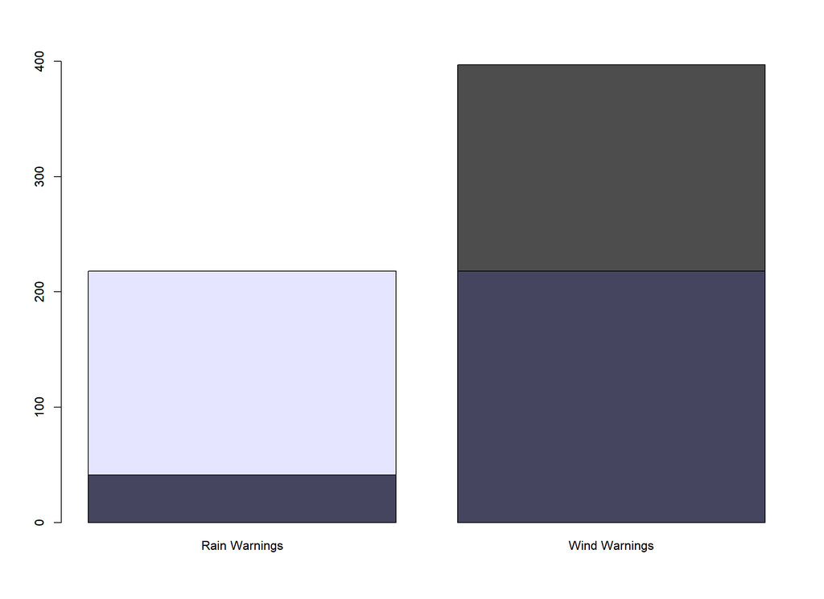

$\small{Figure}$ $\small{6:}$ $\small{Observed}$ $\small{and}$ $\small{Expected}$

#### Storm Ophelia

Storm Ophelia hits Ireland, prompting the first-ever severe weather alert for the entire country. -Oct 16, 2017.

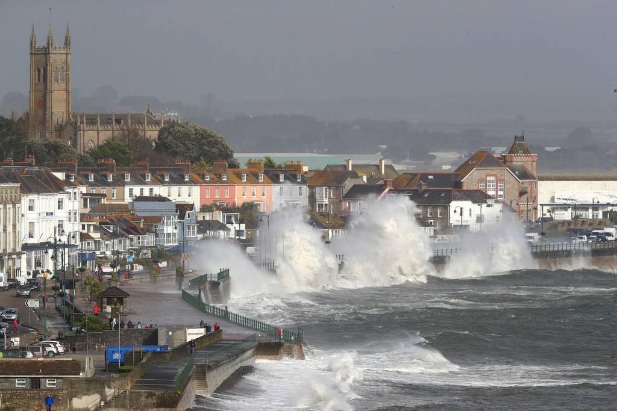

Storm Ophelia’s Impact

Ophelia was regarded as the worst storm to have affected Ireland in the last 50 years and was also the easternmost Atlantic major hurricane on record.

##### Analysis on Storm Ophelia

```r
o <- observations %>%
  filter(month==10, day==16)
head(o)
```

```
## # A tibble: 6 x 12
##   station  year month   day  hour date                 rain  temp  rhum   msl  wdsp wddir
##   <chr>   <dbl> <dbl> <int> <int> <dttm>              <dbl> <dbl> <dbl> <dbl> <dbl> <dbl>
## 1 ATHENRY  2017    10    16     0 2017-10-16 00:00:00   0.4   9.9    95 1011.     7    20
## 2 ATHENRY  2017    10    16     1 2017-10-16 01:00:00   0.3   9.9    95 1010.     7    10
## 3 ATHENRY  2017    10    16     2 2017-10-16 02:00:00   0.4   9.9    95 1009.     8    10
## 4 ATHENRY  2017    10    16     3 2017-10-16 03:00:00   0     9.8    95 1006.     9    20
## 5 ATHENRY  2017    10    16     4 2017-10-16 04:00:00   0.5   9.9    95 1006      9    40
## 6 ATHENRY  2017    10    16     5 2017-10-16 05:00:00   0.1  10.5    96 1002.    12    40
```

##### Wind Direction Analysis

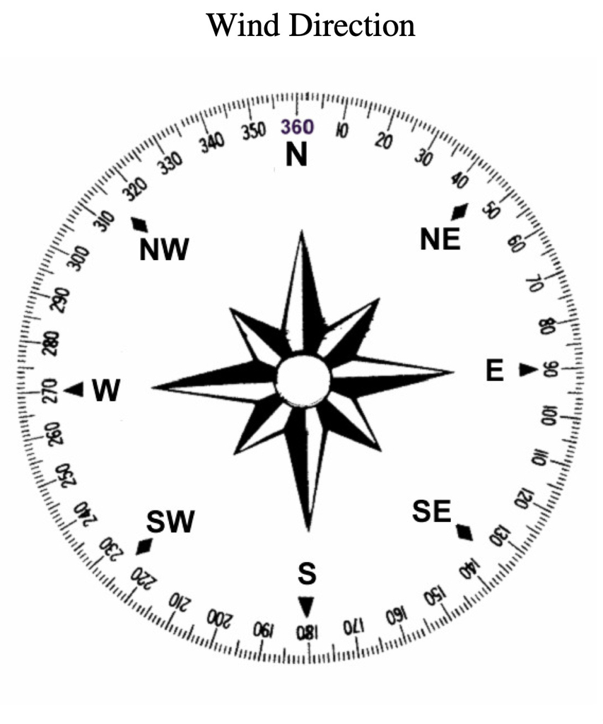

Major Wind Angles

| Direction of Wind is coming from | Angle(in Degree) |
| --- | --- |
| North | 0 |
| East | 90 |
| South | 180 |
| West | 270 |

Now let’s take a look at the direction of wind coming in to the weather stations. So, we are considering the station which had the maximum impact of wind speed. Roches Point, in Cork had the maximum impact of wind due to the Storm Ophelia.

```r
highest<- o %>% arrange(desc(wdsp)) %>%
  slice(1:1) %>%
  pull(station) %>%
  unique()
highest
```

```
## [1] "ROCHES POINT"
```

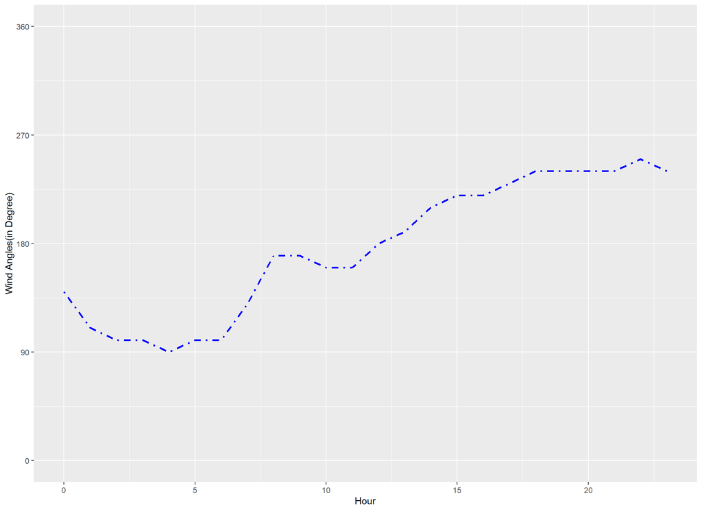

$\small{Figure}$ $\small{7:}$ $\small{Wind}$ $\small{Direction}$ $\small{at}$ $\small{Roches}$ $\small{Point}$ $\small{On}$ $\small{October}$ $\small{16th,}$ $\small{based}$ $\small{on}$ $\small{Hour}$

By looking into the above plot, we can clearly say that at Roches Point on October 16th morning the Wind started from the South-East direction. Later from noon during the storm, wind occurred constantly from South-West direction hitting towards North-East direction in Ireland till EOD on October 16th.

##### Rainfall Analysis

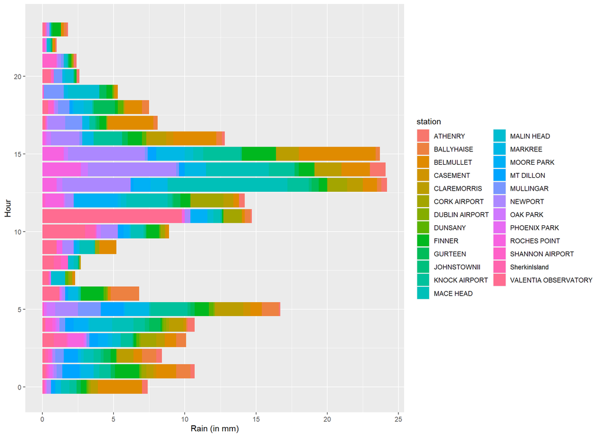

$\small{Figure}$ $\small{8:}$ $\small{Rainfall}$ $\small{across}$ $\small{all}$ $\small{Stations}$ $\small{on}$ $\small{October}$ $\small{16th}$

Number of records gathered:

```r
#number of records gathered
o %>%
  group_by(station, day) %>%
  summarise(TotalObservations=n()) %>%
  pivot_wider(names_from = day,values_from = TotalObservations) %>%
  print(n=25)
```

```
## # A tibble: 25 x 2
## # Groups:   station [25]
##    station               `16`
##    <chr>                <int>
##  1 ATHENRY                 24
##  2 BALLYHAISE              24
##  3 BELMULLET               24
##  4 CASEMENT                24
##  5 CLAREMORRIS             24
##  6 CORK AIRPORT            24
##  7 DUBLIN AIRPORT          24
##  8 DUNSANY                 24
##  9 FINNER                  24
## 10 GURTEEN                 24
## 11 JOHNSTOWNII             24
## 12 KNOCK AIRPORT           24
## 13 MACE HEAD               24
## 14 MALIN HEAD              24
## 15 MARKREE                 24
## 16 MOORE PARK              24
## 17 MT DILLON               24
## 18 MULLINGAR               24
## 19 NEWPORT                 24
## 20 OAK PARK                24
## 21 PHOENIX PARK            24
## 22 ROCHES POINT            24
## 23 SHANNON AIRPORT         24
## 24 SherkinIsland           24
## 25 VALENTIA OBSERVATORY    24
```

Order the hour from driest to wettest:

```r
#Order the hour from driest to wettest
o %>%
  group_by(hour) %>%
  summarise(TotalRainfall=sum(rain,na.rm = T)) %>%
  arrange(TotalRainfall) %>%
  print(n=12)
```

```
## # A tibble: 24 x 2
##     hour TotalRainfall
##    <int>         <dbl>
##  1    22           1
##  2    23           1.8
##  3     7           2.3
##  4    21           2.4
##  5    20           2.6
##  6     8           2.7
##  7     9           5.2
##  8    19           5.3
##  9     6           6.8
## 10     0           7.4
## 11    18           7.5
## 12    17           8.1
## # ... with 12 more rows
```

```r
#Finally, order the weather stations from driest to wettest, with an index value where 3 is the wettest on a day for 2017 (Newport!)
o %>%
  group_by(station) %>%
  summarise(TotalRainfall=sum(rain,na.rm = T)) %>%
  arrange(TotalRainfall) %>%
  mutate(Index=3*TotalRainfall/max(TotalRainfall)) %>%
  print(n=25)
```

```
## # A tibble: 25 x 3
##    station              TotalRainfall  Index
##    <chr>                        <dbl>  <dbl>
##  1 DUBLIN AIRPORT                 0.8 0.0934
##  2 PHOENIX PARK                   1   0.117
##  3 JOHNSTOWNII                    1.4 0.163
##  4 CASEMENT                       1.5 0.175
##  5 DUNSANY                        2.2 0.257
##  6 SherkinIsland                  2.6 0.304
##  7 OAK PARK                       3.4 0.397
##  8 SHANNON AIRPORT                4   0.467
##  9 ATHENRY                        4.5 0.525
## 10 GURTEEN                        6.6 0.770
## 11 MT DILLON                      7.3 0.852
## 12 CORK AIRPORT                   7.7 0.899
## 13 MULLINGAR                      8   0.934
## 14 MOORE PARK                     8.1 0.946
## 15 BALLYHAISE                     8.4 0.981
## 16 ROCHES POINT                   8.8 1.03
## 17 MALIN HEAD                     9   1.05
## 18 MARKREE                       12.1 1.41
## 19 CLAREMORRIS                   12.8 1.49
## 20 FINNER                        14.1 1.65
## 21 KNOCK AIRPORT                 15.1 1.76
## 22 VALENTIA OBSERVATORY          19   2.22
## 23 MACE HEAD                     22.7 2.65
## 24 BELMULLET                     25.5 2.98
## 25 NEWPORT                       25.7 3
```

```r
#The stations with the highest rainfall hourly can be found
highest<- o %>% arrange(desc(rain)) %>%
  slice(1:10) %>%
  pull(station) %>%
  unique()
highest
```

```
## [1] "VALENTIA OBSERVATORY" "MACE HEAD"            "NEWPORT"              "BELMULLET"            "MOORE PARK"
```

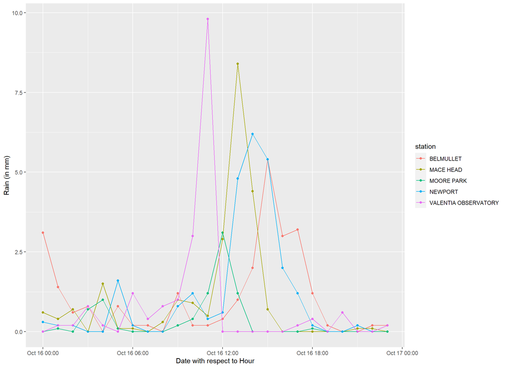

##### Wind Speed Analysis

The stations with the highest mean hourly wind speed on October 16th:

```r
#The stations with the highest mean hourly wind speed can be found
highest<- o %>% arrange(desc(wdsp)) %>%
  slice(1:15) %>%
  pull(station) %>%
  unique()
highest
```

```
## [1] "ROCHES POINT"    "SherkinIsland"   "CORK AIRPORT"    "SHANNON AIRPORT" "CASEMENT"
```

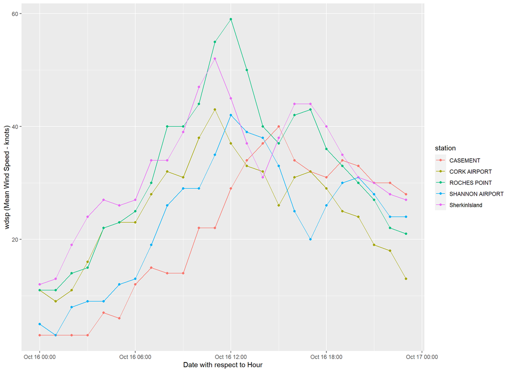

$\small{Figure}$ $\small{10:}$ $\small{Top}$ $\small{Five}$ $\small{Stations}$ $\small{with}$ $\small{Heighest}$ $\small{wind speed}$ $\small{on}$ $\small{October}$ $\small{16th}$

In our analysis we can show the 24-hour windspeed changes. The top 5 stations with highest windspeed are represented on the above plot. The heatmap plot below, showcases the duration of high windspeed detection on Oct 16.

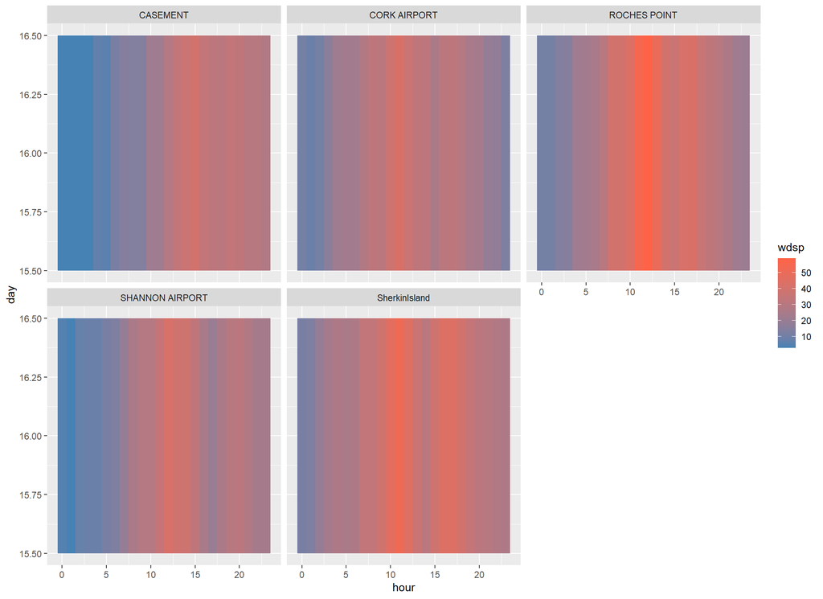

$\small{Figure}$ $\small{11:}$ $\small{Heat}$ $\small{Map}$ $\small{of}$ $\small{wind speed}$ $\small{by}$ $\small{Hour}$ $\small{on}$ $\small{October}$ $\small{16th}$

### Summary

Understanding how weather events get classified according to their severity is important for day-to-day life. Ireland’s geographical location is a prime reason why this is critical. Facing directly towards the Atlantic Ocean means that weather events are numerous throughout the year. Correct weather classifications are crucial if safety measures need to be put in place.

The idea of the research presented in this project was to analyse weather station data to help us understand which regions of Ireland experience the most weather events. In our analysis, it was found that there were major differences between stations. Particularly, out of the 436 records of daily weather events, it was seen that the top 5 stations had 64% of total weather event recordings. This is convincing evidence that stations facing the Atlantic Ocean recorded the majority of weather events.